# Contraste de hipótesis. Proyecto gatos

# A/B testing.

El término test A/B se utiliza para describir experimentos aleatorios con dos variantes, A y B, siendo una la de control y la otra la variante.

Se utiliza ampliamente en el campo del diseño de páginas web (especialmente, cuando se diseñan experiencias de usuario) el objetivo es identificar los cambios que incrementan o maximizan un resultado determinado, como por ejemplo realizar más click en un botón determinado de la web.

## Caso de uso: diseño experimental.

Supongamos el siguiente experimento, tenemos una página web para adoptar mascotas que han sido abandonadas. En primer lugar se colocó una foto de un gatito que daba pena al lado del botón de “Adopta ahora” y se quería saber si en lugar de esa foto, una foto más vistosa de un gatito, incrementaría el número de adopciones de las personas que visitaran la web.

En resumen, estamos tratando con el siguiente problema:

- Cuestión: ¿Cambiar la foto de la página de inicio resultará en más clics de “ADOPTAR AHORA”?
- Hipótesis: Usar una foto de un gato más mono resultará en más clics de “ADOPTAR AHORA”.
- Variable dependiente: Haga clic en el botón “ADOPTAR AHORA” o no.
- Variable independiente: Foto de la página de inicio.

Observa, que el test A/B hace referencia a analizar qué sucede como resultado de un experimento.

### Datos originales con el gatito feo.

```r
# cargar la librería tidyverse
library(tidyverse)

# Leer el dataset click_data.csv
click_data <-read.csv("dataset/click_data.csv")
click_data
```

| visit_date | clicked_adopt_today |
| --- | --- |
| 2017-01-01 | 1 |
| 2017-01-02 | 1 |
| 2017-01-03 | 0 |
| 2017-01-04 | 1 |
| 2017-01-05 | 1 |
| 2017-01-06 | 0 |
| 2017-01-07 | 0 |
| 2017-01-08 | 0 |
| 2017-01-09 | 0 |
| 2017-01-10 | 0 |

[output cut: 990 more lines]

```r
# Obtener el máximo y mínimo del dataset de la columna visit_date
oldest <- max(click_data$visit_date)
recent <- min(click_data$visit_date)

oldest
```

```
[1] "2017-12-31"
```

```r
recent
```

```
[1] "2017-01-01"
```

### Conversion rate o tasa de conversión.

Vamos a calcular la línea base de ratio de conversión de la página web. El ratio de conversión es la media de personas que visitan una página web y realiza la acción que esperamos. Y la línea base se define como el número de acciones realizadas con éxito en la página web en media.

```r
# Utilizamos la función summarize de dplyr y usando el conector pepe conectamos nuestros datos con la función.
click_data %>%
   summarize(conversion_rate = mean(clicked_adopt_today))
```

| conversion_rate |
| --- |
| 0.2772603 |

```r
# usar la función mean para
                                                            # obtener promedio
```

Lo que significa que unos 27 de cada 100 visitantes del sitio web al que se ha hecho clic “Adopta ahora” con la imagen actual de la página de inicio. Este cálculo del ratio de conversión se ha hecho para todo el año, pero podemos realizar este cálculo por meses, ya que puede que en ciertos meses la gente esté más propensa a adoptar mascotas. Para ello utilizamos: - la función group_by del paquete dplyr - la función month del paquete lubridate

```r
# Carga la librería lubridate
library(lubridate)

click_data %>%
   group_by(month(visit_date)) %>%
    summarize(conversion_rate = mean(clicked_adopt_today))
```

| month(visit_date) | conversion_rate |
| --- | --- |
| 1 | 0.1967742 |
| 2 | 0.1892857 |
| 3 | 0.1451613 |
| 4 | 0.1500000 |
| 5 | 0.2580645 |
| 6 | 0.3333333 |
| 7 | 0.3483871 |
| 8 | 0.5419355 |
| 9 | 0.2933333 |
| 10 | 0.1612903 |

[output cut: 2 more lines]

También se podría observar el ratio de conversión por semana utilizando la función week:

```r
# Calculate the mean conversion rate by week of the year
click_data %>%
  group_by(week(visit_date)) %>%
  summarize(conversion_rate = mean(clicked_adopt_today))
```

| week(visit_date) | conversion_rate |
| --- | --- |
| 1 | 0.2285714 |
| 2 | 0.2428571 |
| 3 | 0.1714286 |
| 4 | 0.1285714 |
| 5 | 0.1571429 |
| 6 | 0.1857143 |
| 7 | 0.2571429 |
| 8 | 0.1714286 |
| 9 | 0.1857143 |
| 10 | 0.2000000 |

[output cut: 43 more lines]

```r
NA
```

Vamos a visualizar el ratio de conversión por semanas utilizando la librería ggplot.

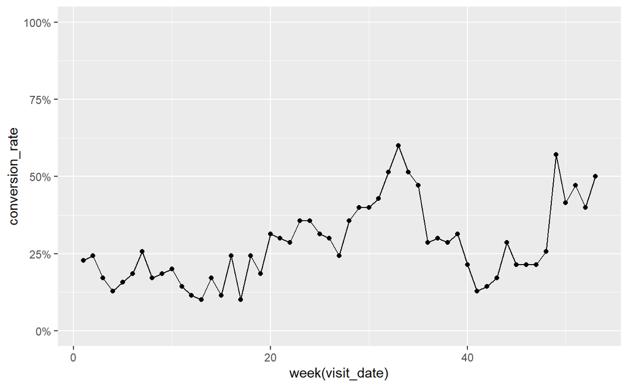

```r
library(scales)

# repite la instrucción anterior de cálculo de ratio de conversion por semanas y almacene dicho resultado en una variable de nombre click_data_sum
click_data_sum <- click_data %>%
  group_by(week(visit_date)) %>%
  summarize(conversion_rate = mean(clicked_adopt_today))

# utilice la función ggplot donde el eje x son las semanas calculadas con la función weeks
# el eje y es el ratio de conversión
ggplot(click_data_sum, aes(x = `week(visit_date)`,
                            y = conversion_rate)) +
   geom_point() + # Función geom_point
   geom_line() + # Función geom_line para el dibujado de la gráfica
   scale_y_continuous(limits = c(0, 1),
                      labels = percent)
```

```r
#También actualizamos nuestro gráfico un poco usando scale_y_continuous() para asegurarnos de que nuestros ejes van de 0 a 1 y convierten los valores a porcentajes. El ajuste porcentual proviene del paquete scales.
```

Este cálculo se realiza para observar cuál es la línea base con la que queremos comparar nuetro experimento. En la gráfica se obsserva que el comportamiento no es constante, en verano y a finales de año la media de personas que realizan la acción que esperamos (ratio de conversión) es mayor, el comportamiento varía según el momento del año.

Este mismo ejercicio por mes quedaría de la siguiente forma:

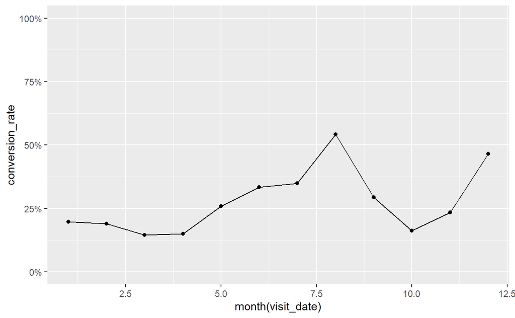

```r
click_data_month <- click_data %>%
   group_by(month(visit_date)) %>%
   summarize(conversion_rate = mean(clicked_adopt_today))

# utilice la función ggplot
ggplot(click_data_month, aes(x = `month(visit_date)`,
                            y = conversion_rate)) +
  geom_point() +
  geom_line() +
   scale_y_continuous(limits = c(0, 1),
                      labels = percent)
```

En el caso de uso, tenemos que diseñar el experimento de dos condiciones: presionar si o no el botón de adoptar ahora. ¿Cuál cree que sería el mejor método para comparar las dos condiciones, es decir, control y test? Elija entre las siguientes opciones:

1. Ejecutar la condición de control durante un mes y luego probar la condición durante un mes.
2. Utilizar los datos antiguos como condición de control y ejecutar la condición de test durante un mes.
3. Ejecutar las condiciones de control y prueba simultáneamente durante dos meses.
4. Ejecutar la condición de control durante un mes, esperar un año y luego ejecutar la condición de prueba durante un mes.